# Python Programming 101 Coding Activity

Presented by Ivan Hernandez

Contact: ivan.hernandez@depaul.edu

## Variables

Variables are a key part of any programming language.

They allow us to take information in one form and give it a symbolic name that we can reference later in the code

We assign information to a variable using the equals symbols:

- The information we want to assign is on the right-hand side
- The name of the variable we want to give that information is on the left-hand side

We can create any name for a variables as long as it begins with a letter and only contains letters and numbers in the name

For example, below, we are taking the number 2, and assigning it to the variable called `a`

Whenever we reference `a`, we are really referencing the number 2

```python
a = 2
print a
```

```
2
```

We can treat the variable as if it were the number and perform operations on it

```python
b = 1
c = 2
d = b + c
print d
```

```
3
```

You can assign values to two variables on the same line if the variables and values are separated by commas

```python
a,b = 4, 5
print a
print b
```

```
4
5
```

## Variable Types

In Python, all information is represented as a "type"

The type represents the format of the information, and lets Python know what can be do with that information (e.g., Can Python add it?, How should Python sort it?")

The three most common types are

- Integers: Whole numbers
- Floats: Decimal numbers
- Strings: Text

### Integer Numbers

Integers are any whole number

Examples of integers are:

- 0
- 1
- 2
- 3
- 99
- -10
- -99

You can check the format of a number with the `type()` function. Integers are denoted by the type "int"

```python
a = 1
b = 3
c = -1

print type(a)
print type(b)
print type(c)
```

```
<type 'int'>
<type 'int'>
<type 'int'>
```

### Things you can do with Integers

If a variable is an integer, you can perform basic arithmetic on it.

Because integers cannot be decimals, if the quotient of two numbers would be a decimal, the result is rounded down to the nearest integer

```python
print 2 + 2
print 3 - 1
print 4 * 2
print 4**2
print 5 / 2
```

```
4
2
8
16
2
```

### Floating Point Numbers (Floats)

Floats (floating point numbers) are decimals such as 0.0, 0.5, 1.0, 2.3333

```python
a = 1.0
b = .5
c = -1.7

print type(a)
print type(b)
print type(c)
```

```
<type 'float'>
<type 'float'>
<type 'float'>
```

### Things you can do with Floats

Floating point numbers allow you to do arithmetic on them, but the results can now take decimal values

```python
print 2.5 + 2.1
print 3.5 - 1.0
print 4.0 * 2.5
print 4.0**2
print 12.5 / 6
```

```
4.6
2.5
10.0
16.0
2.08333333333
```

### Converting integers into floats and vice versa

If you havea number that is an integer and you need to make it into a float, then use the float() function

If you have a number that is a float and you need to make it into an integer, then use the int() function

```python
print float(2)
print int(2.0)
```

```
2.0
2
```

### Strings

Strings are simply text that correspond to characters. Number can be strings if you want them interepreted as representing text and not a numeric value

As long as the information is contained within either single-quotes or double quotes, then the information will be stored as a string

```python
a = "Hello"
b = "2.6666"
c = '-1.7'

print type(a)
print type(b)
print type(c)
```

```
<type 'str'>
<type 'str'>
<type 'str'>
```

### Things you can do with Strings

```python
print "hello" + "goodbye" #Combine two strings into one string

print "Hello".upper() #Uppercase all of the letter
print "Hello".lower() #Lowercase all of the letters

print "Hello".replace("H", "C") #Replace letters with other letters

print "Hello".isalpha() #Check if all characters are alphabetical
print "Hello".isdigit() #Check if all characters are digits

print "Hello Goodbye".split(" ") #Split the word into two words when a space is found
print "_".join(["Hello", "Goodbye"]) #Join two words by an underscore
```

```
hellogoodbye
HELLO
hello
Cello
True
False
['Hello', 'Goodbye']
Hello_Goodbye
```

### Converting numbers into strings

You can convert numbers into strings using the str function

```python
a = str(2)
b = str(2.0)

print type(a)
print type(b)
```

```
<type 'str'>
<type 'str'>
```

# Now you try

Make variable called var and set it equal to the word "five"

Make another variable called var2 and set it equal to 5

Make a third variable called var3 and set it equal to 5.0

What type of variable is each one? Verify your answer with the *type* function

## Storing a collection of Information

Multiple pieces of information, such as integers, floats, and strings can be stored together in a single variable.

There are three commonly used data structures that contain a collection of information:

- Lists: An expandable sequence of information
- Tuples: A fixed sequence of information
- Dictionaries: A collection of values that can be looked up by an associated term

### Lists

#### Creating a List

We create lists using square brackets: [ ]

The items inside the brackets are what we want to store in the order we want to store them.

A list can hold items of any type - including other lists

Each item in the list must be separated by a comma

```python
lst = [1, "4" , 3.2]
print lst
```

```
[1, '4', 3.2]
```

#### Examining the number of items in a list

Because a list contains a collection of items, you may want to know how many items are in that list.

You can apply the *len* function to know the length of the list

You can also use the *len* function to know how many characters are in a string

```python
lst1 = []
lst2 = [1]
lst3 = [1,5,7]
lst4 = [1,5,7,9]


print len(lst2)
print len(lst3)
print len(lst4)
```

```
1
3
4
```

#### Accessing a specific item in a list

Because each list is ordered, we can access specific items in the list by indicating that item's position.

The first item has position 0

The second item has position 1

You can also use a negative sign to indicate that you want to access the list backwards.

If you use position -1, you access the last item in the list

If you use position -2, you access the second to last item in the list

```python
print lst[0] #First item
print lst[1] #Second Items
print lst[-1] #Last item
print lst[0:2] #First through second item
```

```
1
4
3.2
[1, '4']
```

#### Changing, Removing, and Adding a specific item

You can replace an item in a specific position by indicating the list, then index, and setting it equal to whatever information you want.

You can remove a specific value from a list using the "remove" function

You can add a value to the end of a list using the "append" function

```python
lst[0] = 500 #Change
lst.remove("4") #Remove
lst.append("Hello") #Add to the end
print lst
```

```
[500, 3.2, 'Hello']
```

#### Reverse a list

```python
lst = ["dog","cat","bird"]
reversedlst = lst[::-1]
print reversedlst
```

```
['bird', 'cat', 'dog']
```

#### Sort the list

If you want to change the order of a list, you can call the "sorted "function

The default is to sort from lowest to highest, but you can also have it sort from highest to lowest with "reverse=True"

```python
print sorted(lst)
print sorted(lst,reverse=True)
```

```
['bird', 'cat', 'dog']
['dog', 'cat', 'bird']
```

#### Make a list contain only unique items

```python
items = [1,1,1,1,2,2,2,1,1,2,2,2,1,1]
uniqueitems = list(set(items))
print uniqueitems
```

```
[1, 2]
```

### Tuples

Tuples are exactly like lists except that their size is set. If a tuples has 3 items, you cannot append or remove items to that tuple.

Because the size of a tuple won't change, they are a slightly more memory efficient way to hold items, when there are thousands of items to store.

```python
tup = (1, "hello", 3.5)
print tup
print tup[0]
```

```
(1, 'hello', 3.5)
1
```

### Dictionaries

Dictionaries are like lists in that they hold a collection of information.

They are different because each piece of information (i.e., a value) is assocatied with a "key"

Dictionaries are basically a "look-up table." The format of a dictionary is similar to this:

| Key | Value |
| --- | --- |
| Illinois | Springfield |
| California | Sacramento |
| New York | Albany |
| Washington | Olympia |

Therefore, you can look-up a specific piece of information if you know its key. If we know the name of a state, we can lookup its capital.

Unlike a list, a dictionary is unordered.

#### Creating a Dictionary

You can create an empty dictionary and add keys and values to it

```python
dictionary = {}
dictionary["Illinois"] = "Springfield"
print dictionary
```

```
{'Illinois': 'Springfield'}
```

If you know the values ahead of time, you can create the dictionary all at once

```python
dictionary = {"Illinois":"Springfield", "California":"Sacramento", "New York":"Albany", "Washington":"Olympia"}
print dictionary
```

```
{'Washington': 'Olympia', 'New York': 'Albany', 'California': 'Sacramento', 'Illinois': 'Springfield'}
```

#### Accessing a specific value with a key

```python
dictionary["Illinois"]
```

```
'Springfield'
```

#### Changing, Deleting, and Adding a value

```python
#Change a value for a specific key
dictionary["Washington"] = "Seattle"

#Remove a key and value
del dictionary["New York"]

#Add a new key and value
dictionary["Florida"] = "Tallahassee"

print dictionary
```

```
{'Washington': 'Seattle', 'Florida': 'Tallahassee', 'California': 'Sacramento', 'Illinois': 'Springfield'}
```

#### View all of the keys in a dictionary

```python
dictionary.keys()
```

```
['Washington', 'Florida', 'California', 'Illinois']
```

#### View all of the values in a dictionary

```python
dictionary.values()
```

```
['Seattle', 'Tallahassee', 'Sacramento', 'Springfield']
```

#### Convert dictionary into a list of tuples

```python
dictionary = {"Person 1":"John", "Person 2" : "Sam", "Person 3" : "Carl"}
dictionary.items()
```

```
[('Person 3', 'Carl'), ('Person 2', 'Sam'), ('Person 1', 'John')]
```

#### Turn two lists into a dictionary

```python
animals = ["dog","cat","fish"]
weights = [50,20,.5]
animaldict = dict(zip(animals,weights))
animaldict
```

```
{'cat': 20, 'dog': 50, 'fish': 0.5}
```

# Now you try

Make dictionary called "namedict" and have its first key be the name of a close friend of yours and that person's phone number

Add another person to the dictionary, and have it hold that person's phone number too

## Functions

A function is a collection of commands that you expect to use regularly, so you combine them under a single name.

These are the steps to making a function in Python:

- Start the line with the word "def", which indicates you are defining a function
- Specify the the name you want to give the function
- Specify variable names it will take as an input to operate on
- Use a colon and start a new line
- Indent all of the lines belonging to that function
- At the end of the function, write result and what informat you want returned

### Make a simple function

Below shows a simple function named `add` that take two parameters: x and y

It then makes a new variable valled result that adds x and y together

The function then returns the value of result back to the user

```python
def add(x,y):
    result = x + y
    return result
```

We can now execute the function by calling it and providing our own variables as the parameters

```python
add(3,5)
```

```
8
```

# Now you try

Make a function that squares a number

The function should take a single input (a number)

The function should return the square of that input

## Importing Libraries

In addition to the functions that come with Python by default, you can also use functions from libraries other people have created. These libraries allow you to perform a wide variety of tasks with Python, and also simplify how much code you need to write.

Each library has a specific name, which you call to import it

### Import a specific library

You import a specific library by writing:

import *libraryname*

You can then access the functions of a library by writing:

*libraryname*.*functionname*()

Let's import the math library and call the *square root* function from it

```python
import math

math.sqrt(9)
```

```
3.0
```

In addition to functions, some libraries also have values in them.

The string library has all of the lowercase and uppercase letters in it

When using a value and not a function, you do not need to use the parentheses ()

```python
import string

string.ascii_letters
```

```
'abcdefghijklmnopqrstuvwxyzABCDEFGHIJKLMNOPQRSTUVWXYZ'
```

### Import a specific function from a specific library

If you do not want to import the entire library, but just a specific function, you can use the *from* command

That way, you do not have write the entire library name when calling the function. You can call the function directly

```python
from math import sqrt

sqrt(9)
```

```
3.0
```

### Commonly Used Libraries

#### Commonly Used Libraries Included in all Python Installations

- os (Manage files and directories on the operatoring system)
- math (Perform mathemtical functions)
- string (Manipulate strings)
- re (Find and Replace text in strings)
- time (Record the time and Delay command execution)
- datetime (Convert dates into different formats)
- cpickle (Save Python objects to the hard drive for later use)
- glob (Find files in a directory)
- [Full list of Standard Python Libraries Here](https://docs.python.org/2/library)

#### Commonly Used Libraries Included in Anaconda

- PIL (Manipulate, Convert and Save Images)
- numpy (Perform avdanced mathematics)
- pandas (Store and Analyze data in a table-like format)
- matplotlib (Create visualizations from Data)
- sqlite (Manage relational databases)
- [Full list of Anaconda Libraries Here](https://docs.continuum.io/anaconda/pkg-docs)

## Program Control

Now that you have a fundamental understanding of variables and functions, you are able to place them sequentially in the code.

If you want to use functions or create variables repreatedly, you can use Loops to have those commands be automated

If you want to use functions or create variables only if certain conditions are met with regard to those variables, then you can use Conditional statements

Types of Control Statements:

- Loops
  - For Loops
  - While Loops
- Conditions
  - If
  - Else
  - Elif

## Loops

Loops perform a sequence of commands repeatedly for either a set number of times or until a condition is met.

### For Loops

A For Loop will perform a command a given number of times.

There are many types of For Loops, but the two most common are:

- For every item that occurs in a list
- For every number in a sequence of numbers

### For item in *Listname*

If you have a list of items and want to perform an action on each of the individual items, then you can use the `for item in listname` loop.

You have to begin with a list which has a name.

Then say: `for item in listname:`

Then indent the line, and write the commands you want followed

The loop will cycle through the items following the commands as many times are there are items.

Whenever you say the variable `item` in that loop, Python thinks you are referring to the current item in the loop.

You don't have to write `item` You can name the list items anything you want.

Below we create a list of names called `lst`

Then we say, for each item in that list, print the item's value

```python
lst = ["Amy", "Ben", "Carol", "David"]

for item in lst:
    print item
```

```
Amy
Ben
Carol
David
```

### Looping through a set of sequential numbers

If you just want a sequence of commands followed a certain number of times, you can make a list of numbers using the range function.

If you want to have a loop that goes for 10 iterations, then just create a list using `range(0,10)` and loop though it

```python
range(0,10)
```

```
[0, 1, 2, 3, 4, 5, 6, 7, 8, 9]
```

```python
lst = range(0,10)

for item in lst:
    print item
```

```
0
1
2
3
4
5
6
7
8
9
```

### Looping through items in a list using sequential numbers

You can also use a list of numbers to index a list or many lists within a for loop.

Below we have two lists: one for people's first names, and one for people's last names.

We create a list of 4 numbers from 0 to 3, and go through each number referencing the name in the current position from both lists

```python
lst = range(0,4)
firstnames = ["Alice", "Bob", "Charles", "Diana"]
lastnames = ["Anderson", "Burwell", "Clybourn", "Diaz"]
for item in lst:
    print firstnames[item] + " " + lastnames[item]
```

```
Alice Anderson
Bob Burwell
Charles Clybourn
Diana Diaz
```

### While Loops

While loops continuously follow a sequence command until a certain condition is no longer true.

Below we set a variable x to be equal to 0.

We create a while loop, where the condition we place is that x must be below 10.

During the while loop print the value of x and then add 1 to x

Eventually x will be equal to 10, and the loop will stop

```python
x = 0
while (x < 10):
    print(x)
    x = x + 1
```

```
0
1
2
3
4
5
6
7
8
9
```

## Conditional Statements

Conditional statements allow our code to run only if a certain condition is met.

The most fundamental form of a conditional statement is the `if` statement.

### If Statements

In the `if` statement, we specify the condition that must be met within parentheses. We then use a color to indicate the end of our conditions.

The next line is indented and we indicate what code Python should execute if the condition was met.

#### If *Variable* is Less Than *Number*

```python
a = 2
b = 3

if (a < 3):
    print "a is less than 3"

if (b < 3):
    print "b is less than 3"
```

```
a is less than 3
```

#### If *Variable* is Less than or Equal to *Number*

```python
a = 2
b = 3

if (a <= 3):
    print "a is less than or equal to 3"

if (b <= 3):
    print "b is less than or equal to 3"
```

```
a is less than or equal to 3
b is less than or equal to 3
```

#### If *Variable* is Equal to *Number/String/List*

```python
a = 3
b = "hello"
c = [1,2,3]

if (a == 3):
    print "a is equal to 3"

if (b == "hello"):
    print "b is equal to 'hello'"

if (c == [1,2,3]):
    print "c is equal to '[1, 2, 3]'"
```

```
a is equal to 3
b is equal to 'hello'
c is equal to '[1, 2, 3]'
```

#### If In *List/String*

```python
a = 2
b = "He"

if (a in [1,2,3]):
    print "a is in [1,2,3]"

if (b in "Hello"):
    print "b is in 'Hello'"
```

```
a is in [1,2,3]
b is in 'Hello'
```

#### If *Variable* is Not In *List/String*

```python
a = 2
b = "Be"

if (a not in [4,5,6]):
    print "a is not in [4, 5, 6]"

if (b not in "Hello"):
    print "b is not in 'Hello'"
```

```
a is not in [4, 5, 6]
b is not in 'Hello'
```

#### If where multiple conditions must all be met: And

```python
a = 2
b = 3

if a < 5 and b < 4:
    print "a is less than 5 and b is less than 4"

if a and b < 5:
    print "both a and b are less than 5"

if a and b < 3:
    print "both a and b are less than 3"
```

```
a is less than 5 and b is less than 4
both a and b are less than 5
```

We could also use multiple `if` statements nested within each other to check for multiple conditions

Make sure to preserve the indentation where needed to show which statements belong to which commands

```python
a = 2
b = 3

if a < 5:
    if b < 4:
        print "a is less than 5 and b is less than 4"

if a < 5:
    if b < 5:
        print "both a and b are less than 5"
```

```
a is less than 5 and b is less than 4
both a and b are less than 5
```

#### If where ANY condition can be met: Or

```python
a = 2
b = 4

if a < 5 or b < 4:
    print "a is less than 5 or b is less than 4 or both"

if a or b < 5:
    print "a or b or both are less than 5"

if a or b < 3:
    print "either a or b or both are less than 3"
```

```
a is less than 5 or b is less than 4 or both
a or b or both are less than 5
either a or b or both are less than 3
```

### Else Statements

When you want the program to do some if the first condition is not satisfied, then you can follow the `if` command with an `else` command.

The instructions that come after `else` are performed only if the first `if` statement does not hold

```python
a = 2.5
if a < 1:
    print "the variable was less than 1"
else:
    print "the variable was not less than 1"
```

```
the variable was not less than 1
```

### Elif Statements

When you anticipate using multiple if statements that are only followed if the previous ones are false, use the `elif` statement after the first `if` statement

```python
a = 2.5
if a < 1:
    print "the variable was less than 1"
elif a < 2:
    print "the variable was less than 2, but greater than 1"
elif a < 3:
    print "the variable was less than 3, but greater than 2"
else:
    print "the variable was greater than 3"
```

```
the variable was less than 3, but greater than 2
```

# Now you try

Make a simple statement that guesses a person sex based on his/her height and weight.

Create two variables, height and weight and set them equal to your height (in inches) and weight (in lbs).

Make a chain of `if` `elif` and `else` commands that follow a pattern similar to this (Feel free to add/customize the rules to your own intuition):

- If the person's weight is over 200, print "male"
- If the person's weight is under 100, print "female"
- If the person's height is under 64, print "female"
- If the person's height is over 65 and their weight is over 160, print "male"
- etc

## Reading and Writing Files

### Open a new file to write information to it

```python
with open("filename.txt","w") as f:
    f.write("Hi")
    f.write("\r\n")
    f.write("Bye")
    f.write("\r\n")
```

### Open a file to read its contents as a single string

```python
with open("filename.txt","r") as f:
    contents = f.read()
    print contents
```

```
Hi
Bye
```

### Open a file to read its contents as a list of lines

```python
with open("filename.txt","r") as f:
    contents = f.read().splitlines()
    print contents
```

```
['Hi', 'Bye']
```

### Open an existing file to add information to it

```python
with open("filename.txt","a") as f:
    f.write("Hi again")
    f.write("\r\n")
```

Let's re-read the file to see the information we just added

```python
with open("filename.txt","r") as f:
    lines = f.read()
    print lines
```

```
Hi
Bye
Hi again
```

# Now you try

Make a list of four names and call that list: `namelist`

Open a new text file called: "names.txt"

For every name in the name list, write the name to a new line

Open the file in and read its contents as a list.

Print the list from the read file, and see if the list matches the one you originally made

### Classes

Classes are a fundamental part of object oriented programming.

Imagine you anticipate frequently applying a set of functions to some variables. Rather than apply those functions separately, we can organize those functions into a common module called a "class"

Classes are a way to take a grouping of functions and data and place them inside a container.

The functions in a class typically have a common goal.

Because a class is a distinct variable, you can create many of them without having them interfere with other variables.

To use a class, you must:

- Start the line with the word "class", which indicates you are defining a class
- Specify the the name you want to give the class
- Indicate that the class is an object
- Specify what you want the module to do when you first call the class (the "init" step)
- Specify additional functions you want the class to do
- Make sure to include "self" as the first parameter when defining a function within a class

Below we see an example of a class that prepares documents to be text analyzed.

The class is called `documentcleaner` and it is initialized with a starting document

There are many functions that the class can perform on the document, which help prepare it for analysis

- Lowercase all of the text
- Remove newline characters
- Remove punctuation
- Remove non-essential words (stopwords) from the text

At the bottom, we call the `documentcleaner` class with a starting piece of text. The different functions are them called. Finally, we can view the document within the class that has been cleaned.

```python
class documentcleaner(object):

    def __init__(self,document):
        self.document = document #set the class's document variable to the document we used to initialized the class
        print "documentcleaner class is initialized" #display this statement when the class is initialized

    def lowercase(self):
        self.document = self.document.lower()

    def remove_newline(self):
        self.document = self.document.replace("\r","")
        self.document = self.document.replace("\n","")

    def remove_punctuation(self):
        self.document = self.document.replace(".","")
        self.document = self.document.replace(",","")
        self.document = self.document.replace("!","")
        self.document = self.document.replace("?","")

    def remove_stopwords(self):
        cleaned = []
        stopwords = ["a", "an", "and", "at", "are", "be", "but", "by", "for", "how", "is","in","of", "on", "to", "the", "with"]
        words = self.document.split(" ")
        for word in words:
            if word not in stopwords:
                cleaned.append(word)
        self.document = " ".join(cleaned)



text = """We choose to go to the moon in this decade and do the other things,
not because they are easy, but because they are hard, because that goal will serve
to organize and measure the best of our energies and skills, because that challenge
is one that we are willing to accept, one we are unwilling to postpone, and one which
we intend to win, and the others, too."""

dc = documentcleaner(text)

dc.remove_newline()
dc.lowercase()
dc.remove_punctuation()
dc.remove_stopwords()

print dc.document
```

```
documentcleaner class is initialized
we choose go moon this decade do other things not because they easy because they hard because that goal will serve organize measure best our energies skills because that challenge one that we willing accept one we unwilling postpone one which we intend win others too
```

# Now you try

A Magic 8-Ball is a toy where a person would ask it a question, shake it, and the 8-Ball would deliver messages that were a form of:

- Yes
- No
- Undecided

For this activity, create a class called `magiceightball`

When the magiceightball class is called, it should say "Ask me a yes or no question"

The class should have a function called `shake`:

When the `shake` function is called, the class should randomly deliver ONE of the possible messages:

- "Most likely"
- "Outlook good"
- "All signs point to yes"
- "Don't count on it"
- "My sources say no"
- "Very doubtful"
- "Ask again later"
- "Cannot predict now"
- "Concentrate and ask again"

Hint: To choose one item randomly from a list of items: import the library called `random` and use the `random.choice()` function

## Make A Trivia Game

Make a trivia game where the computer displays a question.

The user must provide an answer.

Depending on the answer provided, the user will either see a message saying that "You are correct" or "That answer is incorrect"

You can get a use's input using the command: answer = raw_input()

When you have coded your game, try to make responses be acceptable regardless of if they are uppercase or lowercase

# Compute the Average of a Given set of Numbers

Make a function that computes the average of a list of numbers.

The function should take a single list as an input

The average is computed by adding up all of the numbers and dividing that sum by the total number of items.

Hints:

- Remember to take into acount the number's type because certain types do not handle division well.
- You may need to create a placeholder variable to start the sum at 0

### Count The Number of Instances of Words in a Sentence

Imagine you were given a collection of text

You want to see how often certain words are mentioned.

Write code the takes a sentence and creates a dictionary containing the total number of times each word occurs

Hint: You'll need to solve many different problems including:

- How to take a sentence and turn it into a list of words
- How to make a dictionary to hold the words and their counts
- How to take a list of words and for each word in that list
  - if it not already in the dictionary as a key, add it to a dictionary and give it a starting value
  - if the word is already in the dictionary, increase its count by 1

## Further Ideas

### Rename all of the files

```python
import glob #Import the glob library
import os #Import the os library

os.chdir("Documents") #Go to the "Documents" directory
textfiles = glob.glob("*.txt") #Find all of the files that end in .txt

for filename in textfiles: #For every filename in those text files
    newfilename = "old_" + filename #Make a new filename that adds old to the beginnig of the original filename
    os.rename(filename,newfilename) #Rename the old file with the new filename
```

### Convert a batch of files from jpg to png

```python
import glob #Import the glob library
from PIL import Image #Import the Image library

jpegfiles = glob.glob("*.jpg") #Get all of the files ending in .jpg in the current directory
for filename in jpegfiles: #For every filename that was found
    img=Image.open(filename) #Open the file with the Image library

    newfilename = filename.replace("jpg","png") #Make a new filename that replaces the .jpg with .png
    img.save(newfilename, "PNG") #Save the opened image with the new filename as a png
```

### Analyze Data

```python
import pandas #Import the pandas library

x=[1,2,3,4,5] #Make a variable called x to hold some data
y=[2,1,5,7,3]  #Make a variable called y to hold some data
dataframe = pandas.DataFrame({'Variable1' : x, 'Variable2' :y}) #Convert x and y into a dataframe

print "Descriptive Statistics"
print dataframe.describe() #Compute descriptive statistics

print "\r\n" #Make a new line

print "Correlation Table"
print dataframe.corr() #Compute the correlation between the variables
```

```
Descriptive Statistics
       Variable1  Variable2
count   5.000000   5.000000
mean    3.000000   3.600000
std     1.581139   2.408319
min     1.000000   1.000000
25%     2.000000   2.000000
50%     3.000000   3.000000
75%     4.000000   5.000000
max     5.000000   7.000000


Correlation Table
           Variable1  Variable2
Variable1   1.000000   0.525226
Variable2   0.525226   1.000000
```

### Visualize Data

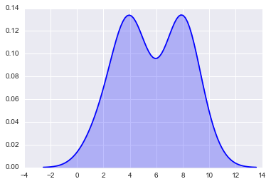

```python
%matplotlib inline
#The above line is needed to make images display in Jupyter

import seaborn #Import the seaborn library for visualization

#Create a dataset
data = [1,2,2,3,3,3,4,4,4,4,4,4,4,4,4,5,5,6,6,7,7,8,8,8,8,8,8,8,8,8,8,9,9,10]

# Plot a simple histogram showing the density (y-axis) of the different numbers (x-axis)
seaborn.distplot(data, hist=False, kde=True, color="b", kde_kws={"shade": True})
```

### Pattern Matching

#### Match word stems

```python
import re #import the regular expression library
fruits = "Strawberries, Bananas, Blackberries, Dates, Raspberries"
re.findall("\w+berries", fruits)
```

```
['Strawberries', 'Blackberries', 'Raspberries']
```

#### Remove digits from string

```python
import re #import the regular expression library
fruits = "Straw343berries, Ban34anas, Blackber678ries, Da678tes, Raspberri234es"
re.sub("\d+", "", fruits)
```

```
'Strawberries, Bananas, Blackberries, Dates, Raspberries'
```

### Scrape Data from the Web

```python
import urllib #Load the urllib library
from bs4 import BeautifulSoup #Load the BeautifulSoup library


url = "https://www.google.com/finance?q=IBM" #The Link to IBM's page on Google Finance

response = urllib.urlopen(url) #Download the webpage
webcontent = response.read() #Read the source code

soup = BeautifulSoup(webcontent, 'html.parser') #Parse the html with BeautifulSoup

stockprice = soup.find("span", {"class": "pr"}) #Get the content in a span tag with a class = "pr"

print stockprice.text #Display the text of that
```

```
150.98
```

### Send e-mails

To use with Gmail, you must go to the following link and select "On": https://myaccount.google.com/lesssecureapps?pli=1

```python
import smtplib

fromaddress='youremailaddress@gmail.com'
toaddress='receipientsemailaddress@gmail.com'

msg = "Hello"
username='youremailaddress@gmail.com'
passwd='YourPassword'

server = smtplib.SMTP('smtp.gmail.com:587')
server.ehlo()
server.starttls()
server.login(username,passwd)
server.sendmail(fromaddress,toaddress,msg)
print("Mail Sent Successfully")
server.quit()
```